# Muestras Complejas

LMT

mayo de 2022

**Encuestas complejas**

Se llama muestra o encuesta compleja cuando se tienen al menos 2 de las siguientes características:

- Estratos
- Varias etapas de muestreo
- Estimadores de razón

Usaremos datos del Censo 2010. [Censo 2010](https://www.inegi.org.mx/programas/ccpv/2010/#Microdatos).

**Descripción de los datos**

Para el levantamiento de la muestra censal 2010 se diseñó un cuestionario ampliado, con el que fueron censadas alrededor de 2.9 millones de viviendas en el país, seleccionadas con criterios probabilísticos.

Consta de 2 cuestionarios: básico y ampliado.

**Objetivos**. Por medio de la muestra censal se estiman tasas, promedios y proporciones.

**Diseño**. El diseño de la muestra censal 2010 es estratificado por conglomerados y se realizó en una sola etapa de selección, es decir, se seleccionan áreas geográficas completas, ya sean manzanas o localidades. Dentro de estas áreas se aplica el cuestionario ampliado a todas las viviendas particulares habitadas

```r
# Limpiar área de trabajo
rm(list = ls())
```

```r
# Cargar librerías
suppressMessages(library(tidyverse))
library(ggplot2)
library(readr)
library(stringr)

library(haven)
```

**Estimación del total de Viviendas en la Ciudad de México**

Leer datos de viviendas

```r
viviendas_09a <- read_sas("/home/leonardo/Documentos/Acatlan/Datos/Censo_2010/MC2010_09_sas/viviendas_09_a.sas7bdat", NULL)
glimpse(viviendas_09a)
```

```
## Rows: 97,838
## Columns: 56
## $ ENT       <chr> "09", "09", "09", "09", "09", "09", "09", "09", "09", "09", …
## $ NOM_ENT   <chr> "Distrito Federal", "Distrito Federal", "Distrito Federal", …
## $ MUN       <chr> "002", "002", "002", "002", "002", "002", "002", "002", "002…
## $ NOM_MUN   <chr> "Azcapotzalco", "Azcapotzalco", "Azcapotzalco", "Azcapotzalc…
## $ LOC50K    <chr> "0001", "0001", "0001", "0001", "0001", "0001", "0001", "000…
## $ NOM_LOC   <chr> "Azcapotzalco", "Azcapotzalco", "Azcapotzalco", "Azcapotzalc…
## $ ID_VIV    <chr> "00922199", "00922204", "00922206", "00922207", "00922208", …
## $ CLAVIVP   <chr> "2", "2", "2", "2", "2", "2", "2", "2", "2", "2", "2", "2", …
## $ PAREDES   <chr> "8", "8", "8", "8", "8", "8", "8", "8", "8", "8", "8", "8", …
## $ TECHOS    <chr> "09", "09", "09", "09", "09", "09", "09", "09", "09", "09", …
## $ PISOS     <chr> "3", "3", "3", "3", "3", "3", "3", "2", "3", "3", "3", "3", …
## $ COCINA    <chr> "1", "1", "1", "1", "3", "1", "1", "1", "1", "1", "1", "1", …
## $ CUADORM   <chr> "03", "03", "03", "03", "01", "03", "03", "03", "02", "01", …
```

[output cut: 43 more lines]

Estimación de Viviendas y Personas (considerando los filtros ocupados por el INEGI)

```r
viviendas_09a %>%
  filter(CLAVIVP %in% c("1","2","3","4","9")) %>%
  mutate(num_personas = parse_number(NUMPERS)) %>%
           summarise(num_viviendas = sum(FACTOR), num_personas = sum(FACTOR*num_personas))
```

```
## # A tibble: 1 x 2
##   num_viviendas num_personas
##           <dbl>        <dbl>
## 1       2440641      8770578
```

Corroboremos los resultados obtenidos usando una librería de R diseñada para muestreo.

Cargamos librería

```r
suppressMessages(library(survey))
```

Filtrar datos

```r
muestra <- viviendas_09a %>%
  filter(CLAVIVP %in% c("1","2","3","4","9")) %>%
  mutate(num_personas = parse_number(NUMPERS),
         unos = 1)
```

Cuando tenemos estratos con 1 sola observación y queremos que no contribuya a la varianza usamos la siguiente opción.

```r
options(survey.lonely.psu = "certainty")
```

Definir diseño

```r
disenio_complejo <-svydesign(id=~UPM,strata = ~ESTRATO, weights=~FACTOR,data=muestra, nest=TRUE)
```

Estimación

```r
estimacion_total_viv <-  svytotal(~unos,disenio_complejo)
estimacion_total_viv
```

```
##        total     SE
## unos 2440641 7966.9
```

Intervalos de Confianza

```r
confint(estimacion_total_viv,level=0.90)
```

```
##          5 %    95 %
## unos 2427537 2453745
```

```r
confint(estimacion_total_viv,level=0.95)
```

```
##        2.5 %  97.5 %
## unos 2425026 2456256
```

Coeficiente de variación

```r
cv(estimacion_total_viv)
```

```
##             unos
## unos 0.003264282
```

Podemos hacer estimaciones por delegación (municipio)

```r
#help("svyby")
est_total_viv_mun <- svyby(~unos, by = ~NOM_MUN, disenio_complejo,svytotal)
est_total_viv_mun
```

```
##                                       NOM_MUN   unos         se
## Álvaro Obregón                 Álvaro Obregón 195716   73.02055
## Azcapotzalco                     Azcapotzalco 119223    0.00000
## Benito Juárez                   Benito Juárez 139399    0.00000
## Coyoacán                             Coyoacán 182140    0.00000
## Cuajimalpa de Morelos   Cuajimalpa de Morelos  47660 3094.69337
## Cuauhtémoc                         Cuauhtémoc 174004 3223.00000
## Gustavo A. Madero           Gustavo A. Madero 320445    0.00000
## Iztacalco                           Iztacalco 101505  480.00000
## Iztapalapa                         Iztapalapa 460221    0.00000
## La Magdalena Contreras La Magdalena Contreras  62897  510.43679
## Miguel Hidalgo                 Miguel Hidalgo 120400    0.00000
## Milpa Alta                         Milpa Alta  30810 4414.34378
## Tláhuac                               Tláhuac  89507 2358.19104
## Tlalpan                               Tlalpan 177562 4034.34291
## Venustiano Carranza       Venustiano Carranza 117487    0.00000
## Xochimilco                         Xochimilco 101665 1313.30871
```

Intervalos de Confianza

```r
confint(est_total_viv_mun,level=0.90)
```

```
##                              5 %      95 %
## Álvaro Obregón         195595.89 195836.11
## Azcapotzalco           119223.00 119223.00
## Benito Juárez          139399.00 139399.00
## Coyoacán               182140.00 182140.00
## Cuajimalpa de Morelos   42569.68  52750.32
## Cuauhtémoc             168702.64 179305.36
## Gustavo A. Madero      320445.00 320445.00
## Iztacalco              100715.47 102294.53
## Iztapalapa             460221.00 460221.00
## La Magdalena Contreras  62057.41  63736.59
## Miguel Hidalgo         120400.00 120400.00
## Milpa Alta              23549.05  38070.95
## Tláhuac                 85628.12  93385.88
## Tlalpan                170926.10 184197.90
## Venustiano Carranza    117487.00 117487.00
## Xochimilco              99504.80 103825.20
```

Grafica de la estimación del número de viviendas.

```r
viviendas_x_municipio <- viviendas_09a %>%
  filter(CLAVIVP %in% c("1","2","3","4","9")) %>%
  mutate(num_personas = parse_number(NUMPERS), unos = 1) %>%
  group_by(ENT, NOM_ENT, MUN, NOM_MUN) %>%
  summarise( registros = n(), num_viviendas = sum(FACTOR), num_personas = sum(FACTOR*num_personas)) %>%
  ungroup()
#viviendas_x_municipio
```

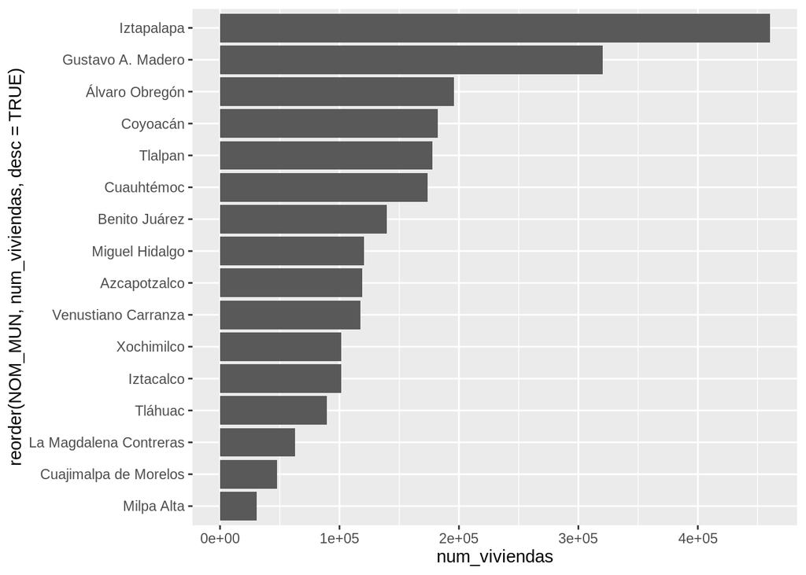

```r
ggplot(data = viviendas_x_municipio) +
geom_col(mapping = aes(x = reorder(NOM_MUN,num_viviendas, desc = TRUE), y = num_viviendas)) +
coord_flip()
```